# Case Study: Linear Regression Modeling of House Prices in Windsor

In this case study, we will utilize the `Housing` dataset from the `Ecdat` package to model house prices in the City of Windsor using linear regression. The objective is to determine which variables most significantly impact house prices.

## Loading Necessary Libraries and Dataset

- Libraries used:
  - `tidyverse` for data manipulation and visualization.
  - `Ecdat` for accessing the `Housing` dataset.
  - `psych` for generating descriptive statistics.
  - `jtools` for summarizing linear models.

```r
pacman::p_load(tidyverse, Ecdat, psych, jtools)
```

## Description of the Data

- The `Housing` dataset contains data about various properties in the City of Windsor, Canada.
- Each row corresponds to a house.
- Includes variables such as lot size, number of bedrooms, and price of the house.

```r
data(Housing)
head(Housing)
```

```
##   price lotsize bedrooms bathrms stories driveway recroom fullbase gashw airco
## 1 42000    5850        3       1       2      yes      no      yes    no    no
## 2 38500    4000        2       1       1      yes      no       no    no    no
## 3 49500    3060        3       1       1      yes      no       no    no    no
## 4 60500    6650        3       1       2      yes     yes       no    no    no
## 5 61000    6360        2       1       1      yes      no       no    no    no
## 6 66000    4160        3       1       1      yes     yes      yes    no   yes
##   garagepl prefarea
## 1        1       no
## 2        0       no
## 3        0       no
## 4        0       no
## 5        0       no
## 6        0       no
```

## Step 1: Explore the Data

### Summary Statistics

- Use the `describe` function from the `psych` package for an overview.

```r
describe(Housing, skew = FALSE,ranges = FALSE,omit = TRUE)
```

```
##          vars   n     mean       sd      se
## price       1 546 68121.60 26702.67 1142.77
## lotsize     2 546  5150.27  2168.16   92.79
## bedrooms    3 546     2.97     0.74    0.03
## bathrms     4 546     1.29     0.50    0.02
## stories     5 546     1.81     0.87    0.04
## garagepl   11 546     0.69     0.86    0.04
```

### Visualizing Relationships

- Scatter plots to visualize relationships between numeric variables and housing price.

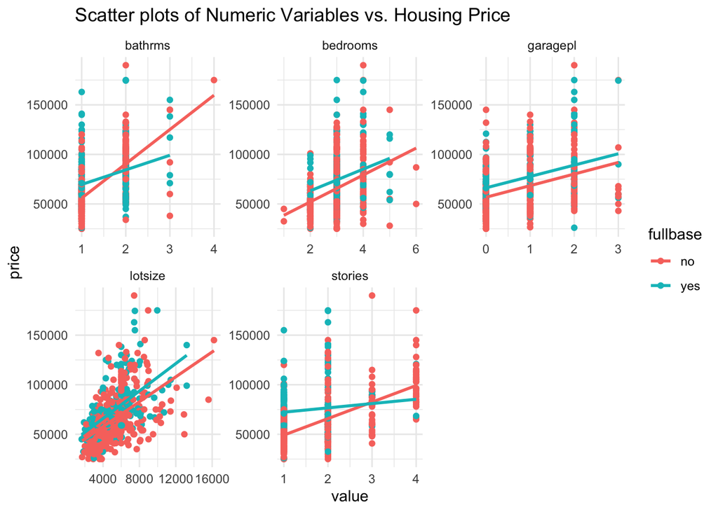

```r
Housing %>%
  pivot_longer(cols = -c(price,!where(is.numeric)), names_to = "variable", values_to = "value") %>%
  ggplot(aes(x=value, y=price, color =fullbase)) +
    geom_point() +
    facet_wrap(~variable, scales="free") +
    geom_smooth(method = "lm",se = FALSE) +
    theme_minimal() +
    labs(title = "Scatter plots of Numeric Variables vs. Housing Price")
```

## Step 2: Estimate Initial Model

- Use the `lm` function to estimate a model using all variables to predict the house price.

```r
model_initial <- lm(price ~ .*fullbase, data = Housing)
summ(model_initial)
```

```
## MODEL INFO:
## Observations: 546
## Dependent Variable: price
## Type: OLS linear regression
##
## MODEL FIT:
## F(21,524) = 53.51, p = 0.00
## R² = 0.68
## Adj. R² = 0.67
##
## Standard errors: OLS
## ------------------------------------------------------------------
##                                     Est.      S.E.   t val.      p
## ----------------------------- ---------- --------- -------- ------
## (Intercept)                     -2927.59   3989.94    -0.73   0.46
## lotsize                             2.95      0.43     6.83   0.00
## bedrooms                         1029.66   1292.86     0.80   0.43
## bathrms                         17703.23   2079.88     8.51   0.00
## stories                          6845.82   1137.17     6.02   0.00
## drivewayyes                      7173.28   2439.35     2.94   0.00
## recroomyes                       1222.95   3299.35     0.37   0.71
## fullbaseyes                      3808.34   7903.27     0.48   0.63
## gashwyes                         7550.94   4019.13     1.88   0.06
## aircoyes                        12610.51   2042.54     6.17   0.00
## garagepl                         3687.41   1059.70     3.48   0.00
## prefareayes                      9020.09   2268.30     3.98   0.00
## lotsize:fullbaseyes                 1.22      0.77     1.59   0.11
## bedrooms:fullbaseyes             1753.10   2244.27     0.78   0.44
## bathrms:fullbaseyes             -6636.71   3018.23    -2.20   0.03
## stories:fullbaseyes             -1295.80   2258.51    -0.57   0.57
## drivewayyes:fullbaseyes         -1360.09   4464.07    -0.30   0.76
## recroomyes:fullbaseyes           3928.59   4060.41     0.97   0.33
## fullbaseyes:gashwyes            12686.80   6901.43     1.84   0.07
## fullbaseyes:aircoyes             -765.35   3212.87    -0.24   0.81
## fullbaseyes:garagepl             1568.08   1744.03     0.90   0.37
## fullbaseyes:prefareayes           565.00   3437.07     0.16   0.87
## ------------------------------------------------------------------
```

### Explanation of Regression Output:

- **Coefficients:**
  - The coefficients represent the change in the dependent variable (house price) for a one-unit change in the predictor variable, while holding other predictors in the model constant.
  - For example, if the coefficient for bedrooms is 2000, it suggests that adding another bedroom increases the house price by $2000, assuming all other factors remain constant.
- **Standard Error:**
  - The standard error measures the accuracy of the coefficient by estimating the variation of the coefficient if the same test were run on a different sample of our population.
  - A smaller standard error indicates a more accurate estimate.
- **t value:**
  - The t value is the coefficient divided by its standard error.
  - It tests the null hypothesis that the coefficient is equal to zero (no effect). A large t value indicates that the null hypothesis can be rejected.
- **p-value:**
  - The p-value represents the probability that the coefficient is actually zero.
  - A low p-value (<0.05) indicates that you can reject the null hypothesis and that the observed relationship is statistically significant.
- **R-squared:**
  - R-squared measures the proportion of the variance in the dependent variable that is predictable from the independent variables.
  - R-squared values range from 0 to 1, where a higher value generally indicates a better fit of the model, assuming certain conditions are met.
- **F-statistic:**
  - The F-statistic tests whether at least one of the predictors’ coefficients is not equal to zero, i.e., it tests the overall significance of the model.
  - A larger F-statistic indicates a more significant model.
- **Residuals:**
  - The residuals represent the difference between the observed value and the value predicted by the model.
  - Analyzing the residuals can help in understanding the appropriateness of the model.

This initial regression output will guide us in refining the model, selecting significant variables, and improving the model fit in the subsequent steps.

## Step 3: Variable Selection

- The `step` function is employed for stepwise regression, automatically selecting predictive variables.
- It adds or removes predictors to meet the specified criteria, primarily AIC, for model comparison.

```r
model_stepwise <- step(model_initial, trace = 0)
summ(model_stepwise)
```

```
## MODEL INFO:
## Observations: 546
## Dependent Variable: price
## Type: OLS linear regression
##
## MODEL FIT:
## F(14,531) = 80.75, p = 0.00
## R² = 0.68
## Adj. R² = 0.67
##
## Standard errors: OLS
## ---------------------------------------------------------------
##                                  Est.      S.E.   t val.      p
## -------------------------- ---------- --------- -------- ------
## (Intercept)                  -3236.43   3600.46    -0.90   0.37
## lotsize                          2.87      0.42     6.88   0.00
## bedrooms                      1625.18   1039.94     1.56   0.12
## bathrms                      17378.48   1993.21     8.72   0.00
## stories                       6365.54    944.92     6.74   0.00
## drivewayyes                   6798.72   2030.01     3.35   0.00
## recroomyes                    3890.67   1899.76     2.05   0.04
## fullbaseyes                   4807.70   4914.95     0.98   0.33
## gashwyes                      7304.63   3977.70     1.84   0.07
## aircoyes                     12463.47   1546.60     8.06   0.00
## garagepl                      4295.51    835.13     5.14   0.00
## prefareayes                   9400.45   1684.88     5.58   0.00
## lotsize:fullbaseyes              1.48      0.66     2.24   0.03
## bathrms:fullbaseyes          -5788.40   2845.82    -2.03   0.04
## fullbaseyes:gashwyes         13260.46   6681.93     1.98   0.05
## ---------------------------------------------------------------
```

### Explanation of the Step Function:

- **Objective:**
  - The `step` function aims to identify a suitable subset of predictors that contribute to explaining the variability in the dependent variable.
  - It helps in eliminating variables that do not significantly contribute to the model, thus refining and simplifying the model.
- **Working Principle:**
  - The function works iteratively, either adding or removing predictors, based on the specified criterion (usually AIC) to find the best-fitted model.
  - In each iteration, it evaluates the impact of adding or removing each variable, selecting the model that best improves the fit.
- **AIC (Akaike Information Criterion):**
  - AIC is a measure used by the `step` function to compare different models.
  - It considers the goodness of fit and the simplicity of the model (i.e., the number of parameters used).
  - Lower AIC values indicate better-fitting models.
- **Significance Level:**
  - The `step` function checks the significance of each variable’s contribution to the model.
  - Variables not meeting the significance threshold (usually a p-value < 0.05 or 0.10) are candidates for removal from the model.
- **Output:**
  - The final output is a refined model with a subset of predictors that collectively contribute significantly to explaining the variability in the dependent variable.

## Step 4: Plot Actual vs. Fitted

- Visualize how well the model’s predictions match the actual prices.

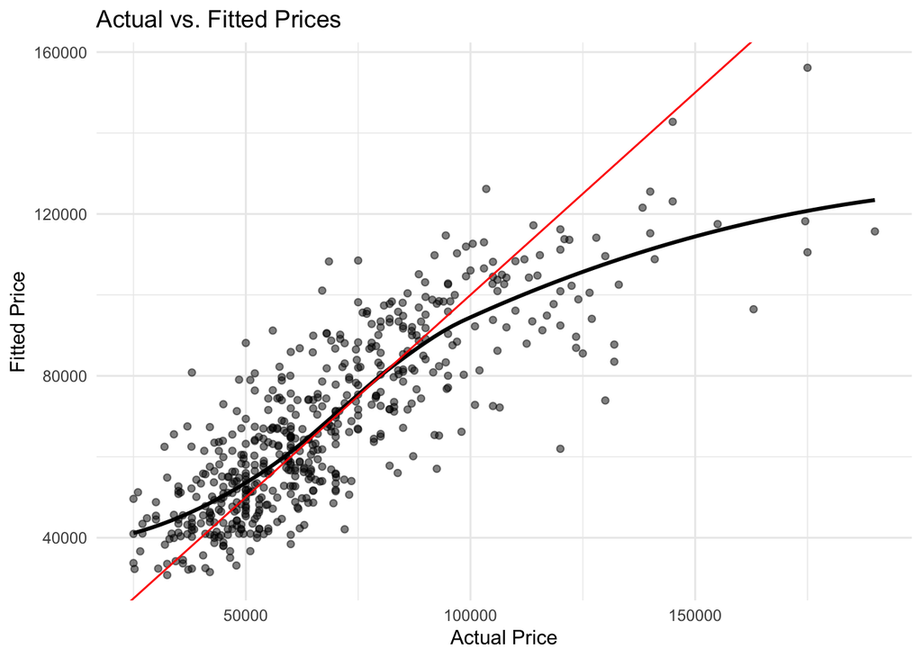

```r
predicted_prices <- predict(model_stepwise)
ggplot(Housing, aes(x = price, y = predicted_prices)) +
  geom_point(alpha = 0.5) +
  geom_smooth(se = FALSE, color = "black") +
  geom_abline(slope = 1, intercept = 0, color = "red") +
  theme_minimal() +
  labs(title = "Actual vs. Fitted Prices", x = "Actual Price", y = "Fitted Price")
```

## Step 5: Re-estimate with a Log-Log Model

- A log-linear model is useful when the underlying relationship appears to be nonlinear.
- Take the natural log of both `price` and `lotsize`.

```r
model_initial_log <- lm(log(price) ~ (. - lotsize + log(lotsize)) * fullbase, data = Housing)
model_log <- step(model_initial_log, trace = 0)
summ(model_log)
```

```
## MODEL INFO:
## Observations: 546
## Dependent Variable: log(price)
## Type: OLS linear regression
##
## MODEL FIT:
## F(13,532) = 90.94, p = 0.00
## R² = 0.69
## Adj. R² = 0.68
##
## Standard errors: OLS
## ---------------------------------------------------------
##                               Est.   S.E.   t val.      p
## -------------------------- ------- ------ -------- ------
## (Intercept)                   7.80   0.22    35.78   0.00
## bedrooms                      0.03   0.01     2.29   0.02
## bathrms                       0.20   0.03     7.33   0.00
## stories                       0.09   0.01     6.71   0.00
## drivewayyes                   0.11   0.03     3.98   0.00
## recroomyes                    0.06   0.03     2.18   0.03
## fullbaseyes                   0.19   0.05     3.41   0.00
## gashwyes                      0.13   0.05     2.32   0.02
## aircoyes                      0.17   0.02     7.79   0.00
## garagepl                      0.05   0.01     4.27   0.00
## prefareayes                   0.14   0.02     6.04   0.00
## log(lotsize)                  0.29   0.03    10.86   0.00
## bathrms:fullbaseyes          -0.07   0.04    -1.78   0.08
## fullbaseyes:gashwyes          0.15   0.09     1.63   0.10
## ---------------------------------------------------------
```

To explain the interpretation of regression coefficients, let’s consider the following four models:

| Model Type | Equation | Interpretation of $\beta_1$ |
| --- | --- | --- |
| Linear | $y = \beta_0 + \beta_1x_1 + \epsilon$ | A 1-unit increase in $x_1$ is associated with a $\beta_1$ unit change in $y$. |
| Log-Linear | $\log(y) = \beta_0 + \beta_1x_1 + \epsilon$ | A 1-unit increase in $x_1$ is associated with a $100 \times \beta_1$ percent change in $y$. |
| Linear-Log | $y = \beta_0 + \beta_1\log(x_1) + \epsilon$ | A 1% increase in $x_1$ is associated with a $\frac{\beta_1}{100}$ unit change in $y$. |
| Log-Log | $\log(y) = \beta_0 + \beta_1\log(x_1) + \epsilon$ | A 1% increase in $x_1$ is associated with a $\beta_1$ percent change in $y$. |

This table should guide the interpretation of the regression coefficients across different model specifications.

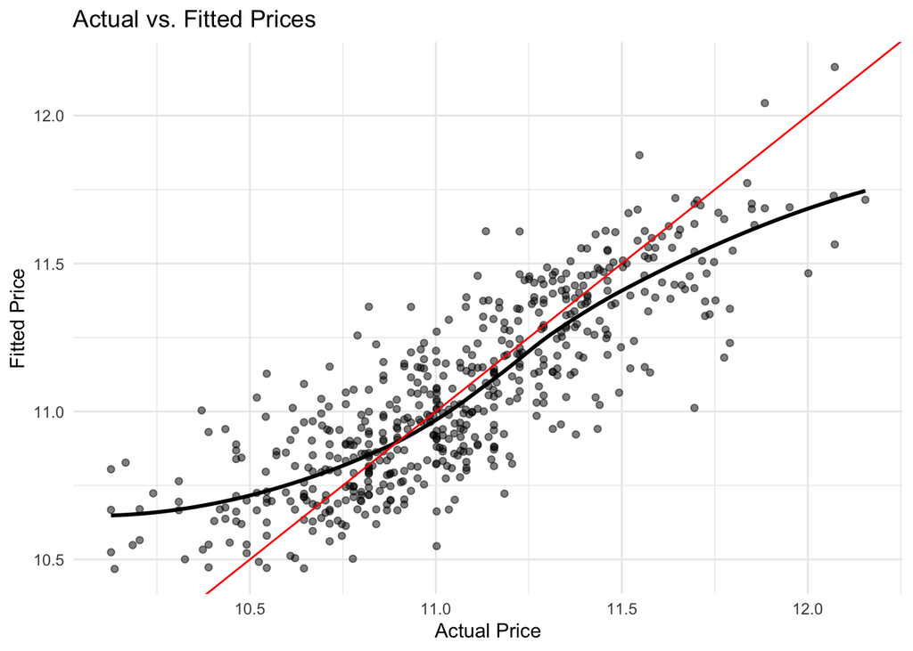

```r
predicted_prices <- predict(model_log)
ggplot(Housing, aes(x = log(price), y = predicted_prices)) +
  geom_point(alpha = 0.5) +
  geom_smooth(se = FALSE, color = "black") +
  geom_abline(slope = 1, intercept = 0, color = "red") +
  theme_minimal() +
  labs(title = "Actual vs. Fitted Prices", x = "Actual Price", y = "Fitted Price")
```

## Step 6: Interpret the Model

- Interpret coefficients in terms of percentage changes.
- Examples of interpretation:
  - For every additional **bedroom**, the house price is expected to increase by approximately 3%.
  - Each additional **bathroom** is associated with a 20% increase in the house price.
  - Having a **driveway** boosts the house price by about 11%.
  - Houses with a **full basement** see a 19% price hike.
  - **Air conditioning** contributes to a 17% price rise.
  - Being in a **preferred area** is associated with a 14% price premium.
  - A 1% increase in **lot size** leads to a 0.29% increase in the house price.
- Interactions like **bathrms:fullbaseyes** and **fullbaseyes:gashwyes** denote the change in the price percentage due to the combined effect of both features.

### Conclusion

- The model’s coefficients give insights into the relative importance and effect of different house features on its price.
- Features like the number of bathrooms, air conditioning, and location in a preferred area have substantial impacts.